# Data Exploration of the NOAA Storm Database (Course Project 2)

Pratyush Mohanty

20 August 2018

## Data Processing

Download and unzip the raw data.

```r
## Download
urlNOAADatabase <- "https://d396qusza40orc.cloudfront.net/repdata%2Fdata%2FStormData.csv.bz2"
download.file(urlNOAADatabase, "NOAADatabase.csv.bz2")
downloadDate <- date()
paste("Data downloaded from \n", urlNOAADatabase, "\n on: ", downloadDate, sep = "")
```

```
## [1] "Data downloaded from \nhttps://d396qusza40orc.cloudfront.net/repdata%2Fdata%2FStormData.csv.bz2\n on: Mon Aug 20 23:43:56 2018"
```

```r
## unzip the file
data_raw <- read.csv("NOAADatabase.csv.bz2", stringsAsFactors = FALSE)

## peek into the data
str(data_raw)
```

```
## 'data.frame':    902297 obs. of  37 variables:
##  $ STATE__   : num  1 1 1 1 1 1 1 1 1 1 ...
##  $ BGN_DATE  : chr  "4/18/1950 0:00:00" "4/18/1950 0:00:00" "2/20/1951 0:00:00" "6/8/1951 0:00:00" ...
##  $ BGN_TIME  : chr  "0130" "0145" "1600" "0900" ...
##  $ TIME_ZONE : chr  "CST" "CST" "CST" "CST" ...
##  $ COUNTY    : num  97 3 57 89 43 77 9 123 125 57 ...
##  $ COUNTYNAME: chr  "MOBILE" "BALDWIN" "FAYETTE" "MADISON" ...
##  $ STATE     : chr  "AL" "AL" "AL" "AL" ...
##  $ EVTYPE    : chr  "TORNADO" "TORNADO" "TORNADO" "TORNADO" ...
##  $ BGN_RANGE : num  0 0 0 0 0 0 0 0 0 0 ...
##  $ BGN_AZI   : chr  "" "" "" "" ...
##  $ BGN_LOCATI: chr  "" "" "" "" ...
##  $ END_DATE  : chr  "" "" "" "" ...
##  $ END_TIME  : chr  "" "" "" "" ...
##  $ COUNTY_END: num  0 0 0 0 0 0 0 0 0 0 ...
```

[output cut: 23 more lines]

```r
head(data_raw, n = 5)
```

```
##   STATE__           BGN_DATE BGN_TIME TIME_ZONE COUNTY COUNTYNAME STATE
## 1       1  4/18/1950 0:00:00     0130       CST     97     MOBILE    AL
## 2       1  4/18/1950 0:00:00     0145       CST      3    BALDWIN    AL
## 3       1  2/20/1951 0:00:00     1600       CST     57    FAYETTE    AL
## 4       1   6/8/1951 0:00:00     0900       CST     89    MADISON    AL
## 5       1 11/15/1951 0:00:00     1500       CST     43    CULLMAN    AL
##    EVTYPE BGN_RANGE BGN_AZI BGN_LOCATI END_DATE END_TIME COUNTY_END
## 1 TORNADO         0                                               0
## 2 TORNADO         0                                               0
## 3 TORNADO         0                                               0
## 4 TORNADO         0                                               0
## 5 TORNADO         0                                               0
##   COUNTYENDN END_RANGE END_AZI END_LOCATI LENGTH WIDTH F MAG FATALITIES
## 1         NA         0                      14.0   100 3   0          0
## 2         NA         0                       2.0   150 2   0          0
## 3         NA         0                       0.1   123 2   0          0
## 4         NA         0                       0.0   100 2   0          0
## 5         NA         0                       0.0   150 2   0          0
##   INJURIES PROPDMG PROPDMGEXP CROPDMG CROPDMGEXP WFO STATEOFFIC ZONENAMES
## 1       15    25.0          K       0
## 2        0     2.5          K       0
## 3        2    25.0          K       0
## 4        2     2.5          K       0
## 5        2     2.5          K       0
##   LATITUDE LONGITUDE LATITUDE_E LONGITUDE_ REMARKS REFNUM
## 1     3040      8812       3051       8806              1
## 2     3042      8755          0          0              2
## 3     3340      8742          0          0              3
## 4     3458      8626          0          0              4
## 5     3412      8642          0          0              5
```

## Analysis

First, let’s have a look at the dataset.

#### Are there any missing values?

```r
dim(data_raw)
```

```
## [1] 902297     37
```

```r
numOfvaluesMissing <- nrow(is.na(data_raw))
percentageMissing <- mean(is.na(data_raw))*100

paste("There are", format(numOfvaluesMissing, big.mark=","), "(=",
      format(round(percentageMissing, 2), big.mark=","),
      "%) missing values.", sep = " ")
```

[output not shown]

#### What are the different event types?

```r
events <- unique(data_raw$EVTYPE)
paste("There are", nrow(events), "types of events recorded. Few examples below.", sep = " ")
```

[output not shown]

```r
head(events, 10)
```

```
##  [1] "TORNADO"                   "TSTM WIND"
##  [3] "HAIL"                      "FREEZING RAIN"
##  [5] "SNOW"                      "ICE STORM/FLASH FLOOD"
##  [7] "SNOW/ICE"                  "WINTER STORM"
##  [9] "HURRICANE OPAL/HIGH WINDS" "THUNDERSTORM WINDS"
```

#### What is the date range covered by the dataset?

```r
## convert the BGN_DATE column to date
data_raw$BGN_DATE <- as.Date(data_raw$BGN_DATE, format = "%m/%d/%Y %H:%M:%S")
minDate <- min(data_raw$BGN_DATE, na.rm = TRUE)
maxDate <- max(data_raw$BGN_DATE, na.rm = TRUE)

paste("The data set ranges from", as.character(minDate), "to",
      as.character(maxDate), ".", sep = " ")
```

```
## [1] "The data set ranges from 1950-01-03 to 2011-11-30 ."
```

To analyse the data, we’ll look at the below questions.  
The questions center around the various event types and their impact to health and economy of the United States.

### Across the United States, which types of events (as indicated in the *EVTYPE* variable) are most harmful with respect to population health?

To answer this, we will group the data by event type, and look at the total number of fatalities and injuries. The top 10 cases are depicted below.

```r
if (!require("dplyr"))
        install.packages("dplyr", quiet = TRUE)
library(dplyr)
```

```r
data_health_impact <-
        as.data.frame(
                data_raw %>%
                group_by(EVTYPE) %>%
                summarise(totalFatalities = sum(FATALITIES),
                          totalInjuries = sum(INJURIES))
        )

## keep only rows where either fatalities or injuries is non zero

data_health_impact<- data_health_impact[
        data_health_impact$totalFatalities != 0 |
                data_health_impact$totalInjuries !=0, ]

data_health_impact$EVTYPE <- as.factor(data_health_impact$EVTYPE)

## take the top 10 causes for fatalities

data_top10_events_for_fatalities <-
        head(
                data_health_impact[
                        order(data_health_impact$totalFatalities, decreasing = TRUE), ],
                n=10)

data_top10_events_for_fatalities
```

```
##             EVTYPE totalFatalities totalInjuries
## 834        TORNADO            5633         91346
## 130 EXCESSIVE HEAT            1903          6525
## 153    FLASH FLOOD             978          1777
## 275           HEAT             937          2100
## 464      LIGHTNING             816          5230
## 856      TSTM WIND             504          6957
## 170          FLOOD             470          6789
## 585    RIP CURRENT             368           232
## 359      HIGH WIND             248          1137
## 19       AVALANCHE             224           170
```

```r
data_top10_events_for_injuries <-
        head(
                data_health_impact[
                        order(data_health_impact$totalInjuries, decreasing = TRUE), ],
                n=10)

data_top10_events_for_injuries
```

```
##                EVTYPE totalFatalities totalInjuries
## 834           TORNADO            5633         91346
## 856         TSTM WIND             504          6957
## 170             FLOOD             470          6789
## 130    EXCESSIVE HEAT            1903          6525
## 464         LIGHTNING             816          5230
## 275              HEAT             937          2100
## 427         ICE STORM              89          1975
## 153       FLASH FLOOD             978          1777
## 760 THUNDERSTORM WIND             133          1488
## 244              HAIL              15          1361
```

```r
if (!require("ggplot2"))
        install.packages("ggplot2", quiet = TRUE)
library(ggplot2)

if (!require("gridExtra"))
        install.packages("gridExtra", quiet = TRUE)
library(gridExtra)
```

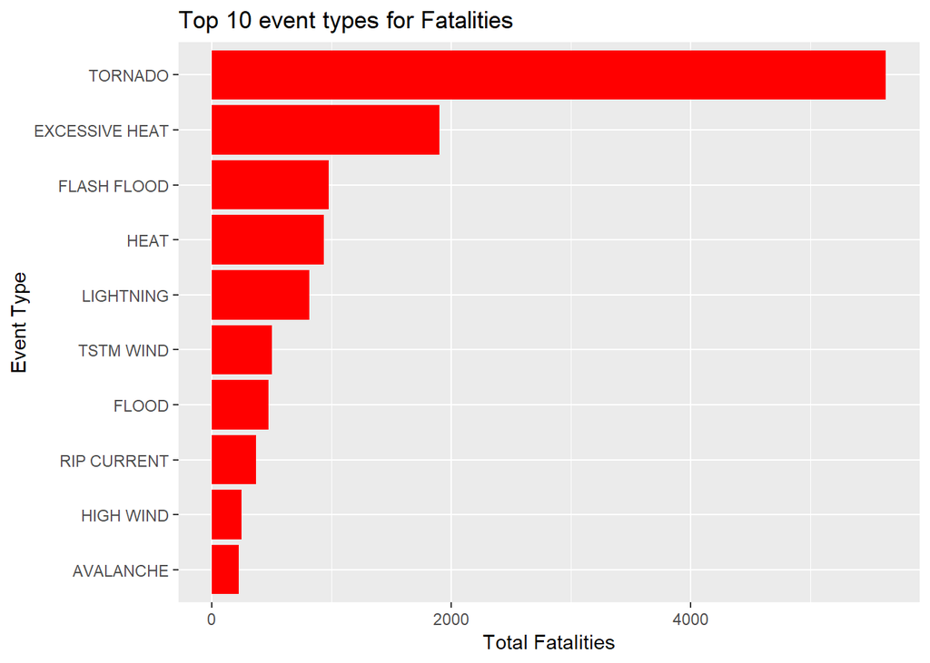

```r
ggplot(data = data_top10_events_for_fatalities,
       aes(x=reorder(EVTYPE, totalFatalities), y=totalFatalities)) +
geom_bar(stat="identity", fill = "red") +
coord_flip() +
ggtitle("Top 10 event types for Fatalities") +
labs(x="Event Type", y="Total Fatalities")
```

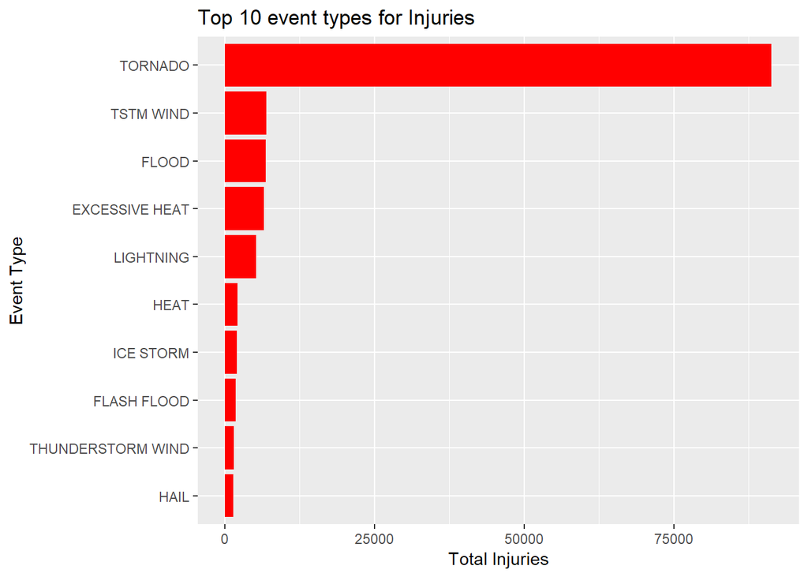

```r
ggplot(data = data_top10_events_for_injuries,
       aes(x=reorder(EVTYPE, totalInjuries), y=totalInjuries)) +
geom_bar(stat="identity", fill = "red") +
coord_flip() +
ggtitle("Top 10 event types for Injuries") +
labs(x="Event Type", y="Total Injuries")
```

### Across the United States, which types of events have the greatest economic consequences?

To assess the economic impact, we will take total of the Crop Damage(CROPDMG) and Property Damage(PROPDMG).

The below is mentioned in the data documentation (pg12) -  
“*Alphabetical characters used to signify magnitude include “K” for thousands, “M” for millions, and “B” for billions.* ”

This analysis will only conside the above 3 characters - K, M, B

```r
## create a function for the multiplier
computeAmount <- function(x, y) {
        if(y=="K" | y=='k') {
                x*1000
        }
        else if(y=="M" | y=='m') {
                x*1000000
        }
        else if(y=="B") {
                x*1000000000
        }
        else {
                0
        }
}

## add a column for calculated crop damage
data_raw$CalculatedCropDamage<- mapply(computeAmount, data_raw$CROPDMG, data_raw$CROPDMGEXP)

## add a column for calculated property damage
data_raw$CalculatedPropertyDamage<- mapply(computeAmount, data_raw$PROPDMG, data_raw$PROPDMGEXP)

## calculate total damage by each event type

data_damage <-
        as.data.frame(
                data_raw %>%
                        group_by(EVTYPE) %>%
                        summarise(totalDamage = sum(CalculatedCropDamage + CalculatedPropertyDamage))
        )

## keep only rows where total damage is non zero
data_damage <- data_damage[data_damage$totalDamage!=0, ]

## Look at the top 10
data_top10_events_for_damages <-
        head(data_damage[order(data_damage$totalDamage, decreasing = TRUE), ], n=10)

data_top10_events_for_damages
```

```
##                EVTYPE  totalDamage
## 170             FLOOD 150319678250
## 411 HURRICANE/TYPHOON  71913712800
## 834           TORNADO  57352113590
## 670       STORM SURGE  43323541000
## 244              HAIL  18758221170
## 153       FLASH FLOOD  17562128610
## 95            DROUGHT  15018672000
## 402         HURRICANE  14610229010
## 590       RIVER FLOOD  10148404500
## 427         ICE STORM   8967041310
```

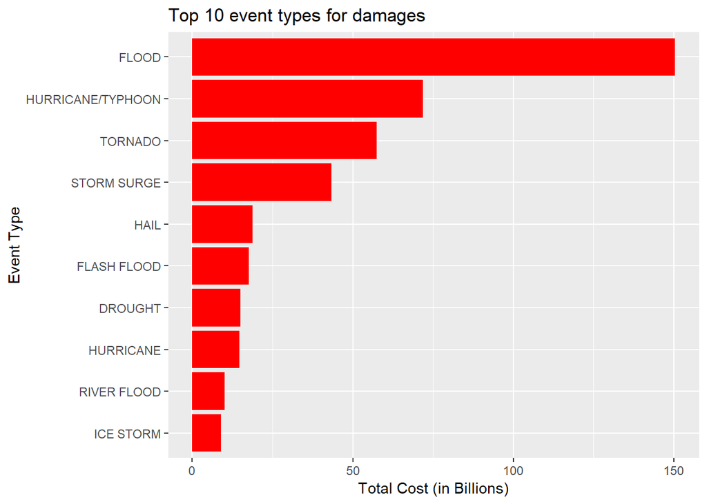

```r
ggplot(data = data_top10_events_for_damages,
               aes(x=reorder(EVTYPE, totalDamage), y=totalDamage/1000000000)) +
        geom_bar(stat="identity", fill = "red") +
        coord_flip() +
        ggtitle("Top 10 event types for damages") +
        labs(x="Event Type", y="Total Cost (in Billions)")
```

## Results

The analysis shows that the top causes for deaths are Tornadoes and Excessive Heat. They also account for most injuries along with Storm winds.

However, Floods cause the biggest economic impact by destroying crops and property.